## Assignment 6

### Yating Tian

#### Due Thursday, October 17

The purpose of this assignment is to review many of the skills you have gained so far in data transformations and analysis. Turn in an HTML file and this R Markdown file after you have edited it.

### Data

The data are in files `obesity-hw.csv`, `rural-urban.csv`, `education.csv`, and `income.csv`. The obesity data set has one row for each zip code by age and sex cohort. The other files have one row per zip code (and have far fewer variables than the original files as we manipulated the data in class).

### 1

> Transform and combine the data sets so that you have two rows for each zip code (one row for each sex) and the following columns of data. Note that you will need to eliminate the data on obesity among children and summarize the data across age cohorts within each zip code to accomplish this task.
- `zip` = zip code
- `sex` = sex (male or female)
- `adult_n` = estimated # of adults (of that sex)
- `obese_n` = estimated # of obese adults (of that sex)
- `obese_p` = estimated proportion of obese adults (of that sex)
- `pct_bach` = % adults (aged 25+, of the given sex) with at least a bachelors degree

```r
obesity = read_csv("obesity-hw.csv") %>%
  mutate(zip=clean.zipcodes(zip))
education=read.csv("education.csv") %>%
  mutate(zip=clean.zipcodes(zip))

obesity1=obesity %>%
  drop_na() %>%
  filter(age != "05-17") %>%
  mutate(obese_n=pop*obese/bmi) %>%
  group_by(zip,sex) %>%
  summarise(adult_n=sum(pop),
            obese_o=sum(obese_n),
            obese_p=sum(obese_n/adult_n))

education=education %>%
  rename(female=pct_f_bach,
         male=pct_m_bach) %>%
  gather(key = sex, value = pct_bach,female,male) %>%
  arrange(zip,sex)

obesity1=left_join(obesity1,education, by=c("zip","sex"))
head(obesity1)
```

```
## # A tibble: 6 x 6
## # Groups:   zip [3]
##   zip   sex    adult_n obese_o obese_p pct_bach
##   <chr> <chr>    <dbl>   <dbl>   <dbl>    <dbl>
## 1 53001 female     671    259.   0.386     23
## 2 53001 male       682    330.   0.483     13
## 3 53002 female     977    369.   0.377     25.4
## 4 53002 male      1052    404.   0.384     16.2
## 5 53004 female    1244    553.   0.445     26.8
## 6 53004 male      1164    604.   0.519     23.3
```

### 2

> Using the data from Question 1, calculate the estimated percentages of obese adults in Wisconsin separately by sex and education and display these values in a 2 by 2 table. State any assumptions you need to make when making these calculations. (Recall that you need to sum up totals of people before finding proportions.)

```r
obesity2 = obesity1 %>%
  mutate(pct_bach_p=pct_bach/100,
         non_bach_p=1-pct_bach_p,
         obese_n=adult_n-obese_o,
         non_obese_p=1-obese_p,
         obese_bach=obese_o*pct_bach_p,
         non_obese_bach=obese_n*pct_bach_p,
         obese_non_bach=obese_o*non_bach_p,
         non_obese_non_bach=obese_n*non_bach_p)

obesity2 %>%
  ungroup()%>%
  select(sex,contains("bach")) %>%
  group_by(sex) %>%
  summarise_all(sum) %>%
  mutate(bach_total=obese_bach+non_obese_bach,
         non_bach_total=obese_non_bach+non_obese_non_bach,
         obese_bach_rate=obese_bach/bach_total,
         obese_non_bach_rate=obese_non_bach/non_bach_total) %>%
  select(sex, contains("rate"))
```

```
## # A tibble: 2 x 3
##   sex    obese_bach_rate obese_non_bach_rate
##   <chr>            <dbl>               <dbl>
## 1 female           0.371               0.417
## 2 male             0.392               0.434
```

### 3

> Make a scatter plot which displays the proportion of a zip code aged 25+ with a bachelor’s degree by sex on the x-axis and the proportion obese by sex on the y axis. Use different colors for each sex and add a trend line or curve for each sex. Create appropriate labels and titles for the plot. Comment on any apparent patterns in the data.

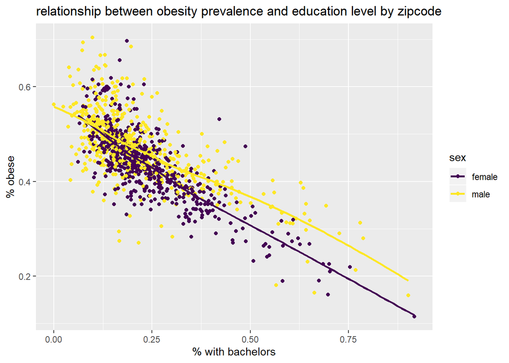

```r
ggplot(obesity2, aes(x=pct_bach_p, y=obese_p,color=sex))+
  geom_point()+
  geom_smooth(se=FALSE)+
  xlab("% with bachelors")+
  ylab("% obese")+
  ggtitle("relationship between obesity prevalence and education level by zipcode")
```

### response the pattern shows that the education and obesity have negetive direct relationship. In other word, the higher education, like bachelor degree, the lower chance to get obese.